# Notebook

### Web Information Retrieval and Data Mining - Assignment 3

```
Student: van den Brandt, Irma (1081110)
```

#### Answer 1.1, Baseline (4p)

- Dense network, at least 3 layers, shaped like a pyramid
  - Last layer: 10 nodes, sigmoid.
  - Loss: categorical cross-entropy. Metric: accuracy
- No preprocessing, regularization. Get at least 70% accuracy.
- Explain design decisions. Discuss performance.
  - Does it overfit (large/growing gap between loss and val_loss)?

[output not shown]

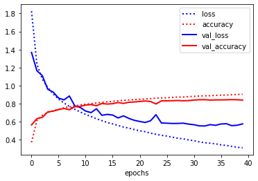

```
Model: "sequential_2"
_________________________________________________________________
Layer (type)                 Output Shape              Param #
=================================================================
reshape_2 (Reshape)          (None, 3072)              0
_________________________________________________________________
dense_4 (Dense)              (None, 1024)              3146752
_________________________________________________________________
dense_5 (Dense)              (None, 512)               524800
_________________________________________________________________
dense_6 (Dense)              (None, 256)               131328
_________________________________________________________________
dense_7 (Dense)              (None, 128)               32896
_________________________________________________________________
dense_8 (Dense)              (None, 10)                1290
=================================================================
Total params: 3,837,066
Trainable params: 3,837,066
Non-trainable params: 0
_________________________________________________________________
None
def build_model_1_1():
    model = models.Sequential()
    model.add(layers.Reshape((3072,), input_shape=(32,32,3)))
    model.add(layers.Dense(1024, activation='relu'))
    model.add(layers.Dense(512, activation='relu'))
    model.add(layers.Dense(256, activation='relu'))
    model.add(layers.Dense(128, activation='relu'))
    model.add(layers.Dense(10, activation='softmax'))

    model.compile(optimizer=optimizers.Adam(learning_rate=0.00001),
                  loss='categorical_crossentropy',
                  metrics=['accuracy'])


    adam = optimizers.Adam(learning_rate=0.00005) #works best
    adagrad = optimizers.Adagrad(learning_rate=0.00005) #similar to adam but slightly worse

    model.compile(optimizer=adam,
                  loss='categorical_crossentropy',
                  metrics=['accuracy'])


    return model
```

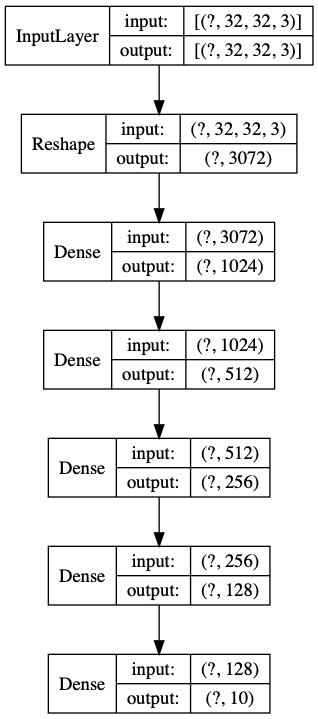

#### Answer 1.2, Preprocess (2p)

- Convert images to greyscale, other preprocessing optional.
  - Input shape should be (32,32,1)
- Explain design decisions. Is it better? Why (not)?
  - Color information is likely not so useful for classification. Greyscale makes the network smaller, less parameters to learn, less likely to overfit.

[output not shown]

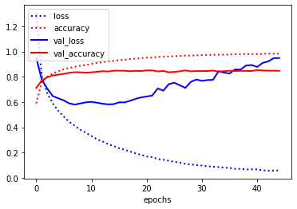

```
Model: "sequential_3"
_________________________________________________________________
Layer (type)                 Output Shape              Param #
=================================================================
reshape_3 (Reshape)          (None, 1024)              0
_________________________________________________________________
dense_9 (Dense)              (None, 1024)              1049600
_________________________________________________________________
dense_10 (Dense)             (None, 512)               524800
_________________________________________________________________
dense_11 (Dense)             (None, 256)               131328
_________________________________________________________________
dense_12 (Dense)             (None, 128)               32896
_________________________________________________________________
dense_13 (Dense)             (None, 10)                1290
=================================================================
Total params: 1,739,914
Trainable params: 1,739,914
Non-trainable params: 0
_________________________________________________________________
None
def build_model_1_2():
    model = models.Sequential()
    model.add(layers.Reshape((1024,), input_shape=(32,32,1)))
    model.add(layers.Dense(1024, activation='relu'))
    model.add(layers.Dense(512, activation='relu'))
    model.add(layers.Dense(256, activation='relu'))
    model.add(layers.Dense(128, activation='relu'))
    model.add(layers.Dense(10, activation='softmax'))

    model.compile(optimizer=optimizers.Adam(learning_rate=0.00005),
                  loss='categorical_crossentropy',
                  metrics=['accuracy'])

    return model
```

#### Answer 1.3, Tune (4p)

- Regularize the model. What works best?
  - Should consider batch normalization, dropout, l1/l2 regularization (or Nesterov)
- Tune other hyperparameters (e.g. learning rate, batch size,...) as you see fit.
  - At least consider tuning learning rate, ideally also momentum, decay, other optimizers
- Explain your findings and final design decisions. Discuss the results.
  - Should be better, at least it shouldn't overfit

```
The train and validation accuracy are very close. Around 35 epochs overfitting starts. (length: 87)

Max val score: 88.25%
```

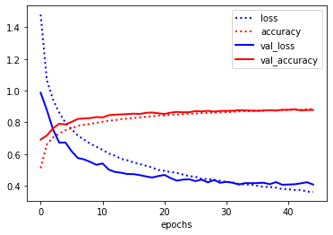

```
def build_model_1_3():
    drop_model = models.Sequential()
    drop_model.add(layers.Reshape((1024,), input_shape=(32,32,1)))

    drop_model.add(layers.Dense(1024))
    drop_model.add(layers.BatchNormalization())
    drop_model.add(Activation('relu'))
    drop_model.add(layers.Dropout(0.2))

    drop_model.add(layers.Dense(512))
    drop_model.add(layers.BatchNormalization())
    drop_model.add(Activation('relu'))
    drop_model.add(layers.Dropout(0.2))

    drop_model.add(layers.Dense(256))
    drop_model.add(layers.BatchNormalization())
    drop_model.add(Activation('relu'))
    drop_model.add(layers.Dropout(0.2))

    drop_model.add(layers.Dense(128))
    drop_model.add(layers.BatchNormalization())
    drop_model.add(Activation('relu'))
    drop_model.add(layers.Dropout(0.2))

    drop_model.add(layers.Dense(10, activation='softmax'))

    drop_model.compile(optimizer=optimizers.Adam(learning_rate=0.001),
                      loss='categorical_crossentropy',
                      metrics=['accuracy'])

    return drop_model
```

#### Answer 2.1, ConvNet (7p)

- Build a sequential ConvNet, get at least 90% accuracy.
  - Conv2D layers, input shape (32,32,1)
  - Consider using blocks of Conv2D layers with maxpooling in between
  - Use zero-padding in Conv2D layers because the images are small
  - At least one dense hidden layer and dense output layer (sigmoid)
  - Consider adding batch normalization, dropout
  - Consider small dropout rates in beginning, larger dropout rates later in network
  - Consider other optimizers and tuning learning rate, momentum,...
- Explain what you did and why (800 chars). Is it working well?
  - Should be quite elaborate and sensible

[output not shown]

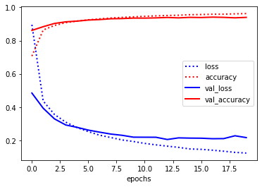

```
Model: "sequential_5"
_________________________________________________________________
Layer (type)                 Output Shape              Param #
=================================================================
conv2d (Conv2D)              (None, 30, 30, 32)        320
_________________________________________________________________
conv2d_1 (Conv2D)            (None, 30, 30, 32)        9248
_________________________________________________________________
batch_normalization_4 (Batch (None, 30, 30, 32)        128
_________________________________________________________________
conv2d_2 (Conv2D)            (None, 30, 30, 32)        9248
_________________________________________________________________
dropout_4 (Dropout)          (None, 30, 30, 32)        0
_________________________________________________________________
max_pooling2d (MaxPooling2D) (None, 15, 15, 32)        0
_________________________________________________________________
conv2d_3 (Conv2D)            (None, 15, 15, 64)        18496
_________________________________________________________________
batch_normalization_5 (Batch (None, 15, 15, 64)        256
_________________________________________________________________
conv2d_4 (Conv2D)            (None, 15, 15, 64)        36928
_________________________________________________________________
dropout_5 (Dropout)          (None, 15, 15, 64)        0
_________________________________________________________________
max_pooling2d_1 (MaxPooling2 (None, 7, 7, 64)          0
_________________________________________________________________
conv2d_5 (Conv2D)            (None, 7, 7, 64)          36928
_________________________________________________________________
batch_normalization_6 (Batch (None, 7, 7, 64)          256
_________________________________________________________________
dropout_6 (Dropout)          (None, 7, 7, 64)          0
_________________________________________________________________
max_pooling2d_2 (MaxPooling2 (None, 3, 3, 64)          0
_________________________________________________________________
flatten (Flatten)            (None, 576)               0
_________________________________________________________________
dropout_7 (Dropout)          (None, 576)               0
_________________________________________________________________
dense_19 (Dense)             (None, 96)                55392
_________________________________________________________________
```

[output cut: 28 more lines]

```
    model.add(layers.Dropout(0.2))
    model.add(layers.MaxPooling2D((2, 2)))

    model.add(layers.Flatten())
    model.add(layers.Dropout(0.2))
    model.add(layers.Dense(96, activation='relu'))
    model.add(layers.Dense(128, activation='relu'))
    model.add(layers.Dense(10, activation='softmax'))


    model.compile(optimizer=optimizers.Adam(learning_rate=0.0003),
              loss='categorical_crossentropy',
              metrics=['accuracy'])

    return model
```

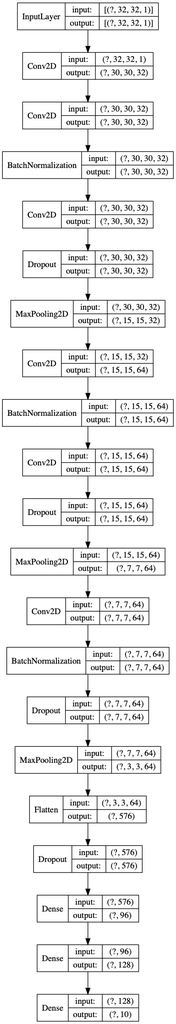

#### Answer 2.2, Data Augmentation (3p)

- Augment the preprocessed training data.
  - Use small variations (small shifts up-down, left-right) of flips becasue the images are small
  - Large shifts and rotations distort the image too much
- Explain what you did and why. Discuss the performance of the model.

[output not shown]

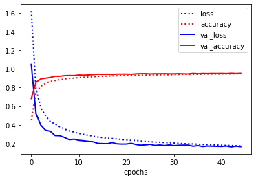

```
datagen_train = ImageDataGenerator(
      rotation_range=10,
      width_shift_range=0.1,
      height_shift_range=0.1,
      shear_range=0.1,
      zoom_range=0.1,
      fill_mode='nearest'
)
```

#### Answer 3.1, Misclassifications (2p)

[output not shown]

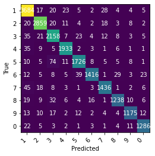

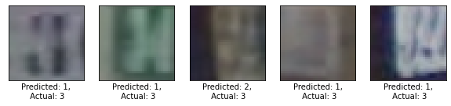

#### Answer 3.2, Activations (4p)

- Retrieve and visualize the activations for one example
- For every filter for different convolutional layers (at different depths in the network).
- Give an explanation. Is your model indeed learning something useful?
  - Should detect edges etc in first layers, higher-order object (e.g. interesting regions) in deeper layers.

[output not shown]

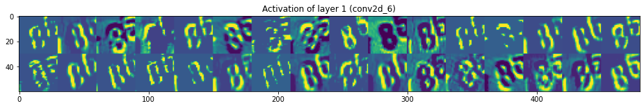

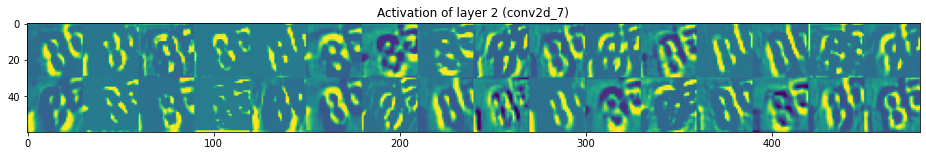

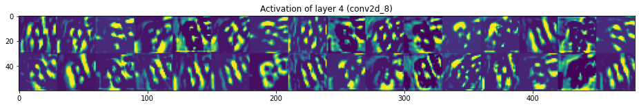

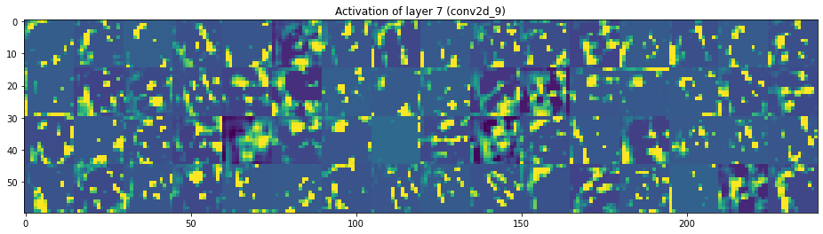

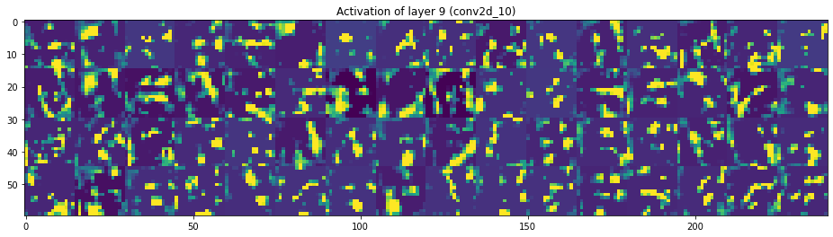

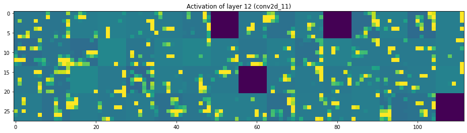

#### Answer 3.3, Class activation map (4p)

- Show a class activation map for your last convolutional layer
- Superimpose the activation map over the image, or plot side by side
  - Should make sense, detect interesting regions to classify the number

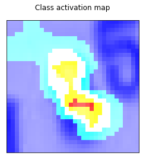

```
def plot_3_3():
    last_conv_layer = model.get_layer('conv2d_11')
    grads = K.gradients(class8_output, last_conv_layer.output)[0]
    pooled_grads = K.mean(grads, axis=(0, 1, 2))

    iterate = K.function([model.input], [pooled_grads, last_conv_layer.output[0]])

    pooled_grads_value, conv_layer_output_value = iterate([img_tensor])

    for i in range(len(pooled_grads_value)):
        conv_layer_output_value[:, :, i] *= pooled_grads_value[i]

    heatmap = np.mean(conv_layer_output_value, axis=-1)

    heatmap = np.maximum(heatmap, 0)
    heatmap /= np.max(heatmap)
    plt.matshow(heatmap)

    # Load the original image in grey scale
    img = X_test_pre[0]

    # Resizing of heatmap to size original image and converting to greyscale
    heatmap = cv2.resize(heatmap, (img.shape[1], img.shape[0]))
    heatmap = np.uint8(255 * heatmap)

    # We apply the heatmap to the original image
    heatmap = cv2.applyColorMap(heatmap, cv2.COLORMAP_JET)

    # 0.4 here is a heatmap intensity factor
    superimposed_img = heatmap * 0.4 + img

    # Convert to float 32
    img_conv = superimposed_img.astype('float32')

    RGB_im = cv2.cvtColor(img_conv, cv2.COLOR_BGR2RGB)
    plt.rcParams['figure.dpi'] = 120
    plt.imshow(RGB_im)
    plt.title('Class activation map')
    plt.xticks([])
    plt.yticks([])
    plt.show()
```

#### Answer 4.1, Fast feature extraction (5p)

- Import the VGG16 model, pretrained on ImageNet
- Freeze convolutional base, adds a dense layer
- Consider unfreezing the last few convolutional layers and evaluate whether that works better
  - Check if they do. It is very likely to help.
- Discuss the observed performance
  - Should get around 80% accuracy

[output not shown]

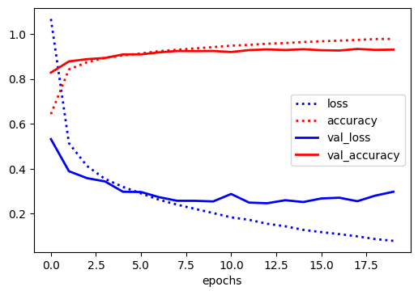

```
Model: "model_16"
_________________________________________________________________
Layer (type)                 Output Shape              Param #
=================================================================
input_6 (InputLayer)         [(None, 32, 32, 3)]       0
_________________________________________________________________
block1_conv1 (Conv2D)        (None, 32, 32, 64)        1792
_________________________________________________________________
block1_conv2 (Conv2D)        (None, 32, 32, 64)        36928
_________________________________________________________________
block1_pool (MaxPooling2D)   (None, 16, 16, 64)        0
_________________________________________________________________
block2_conv1 (Conv2D)        (None, 16, 16, 128)       73856
_________________________________________________________________
block2_conv2 (Conv2D)        (None, 16, 16, 128)       147584
_________________________________________________________________
block2_pool (MaxPooling2D)   (None, 8, 8, 128)         0
_________________________________________________________________
block3_conv1 (Conv2D)        (None, 8, 8, 256)         295168
_________________________________________________________________
block3_conv2 (Conv2D)        (None, 8, 8, 256)         590080
_________________________________________________________________
block3_conv3 (Conv2D)        (None, 8, 8, 256)         590080
_________________________________________________________________
block3_pool (MaxPooling2D)   (None, 4, 4, 256)         0
_________________________________________________________________
block4_conv1 (Conv2D)        (None, 4, 4, 512)         1180160
_________________________________________________________________
block4_conv2 (Conv2D)        (None, 4, 4, 512)         2359808
_________________________________________________________________
block4_conv3 (Conv2D)        (None, 4, 4, 512)         2359808
_________________________________________________________________
block4_pool (MaxPooling2D)   (None, 2, 2, 512)         0
_________________________________________________________________
block5_conv1 (Conv2D)        (None, 2, 2, 512)         2359808
_________________________________________________________________
block5_conv2 (Conv2D)        (None, 2, 2, 512)         2359808
_________________________________________________________________
block5_conv3 (Conv2D)        (None, 2, 2, 512)         2359808
_________________________________________________________________
```

[output cut: 24 more lines]

```
    predictions = layers.Dense(10, activation='softmax', name='dense_10_class')(VGG_model)

    # trainig model
    model = models.Model(inputs=conv_base.input, outputs=predictions)

    # Setting the number of layers that are freezed
    for index, layer in enumerate(model.layers):
        if index < 7:
            layer.trainable = False
        else:
            layer.trainable = True

    model.compile(optimizers.Adam(learning_rate=0.00001), loss='categorical_crossentropy', metrics=['accuracy'])

    return model
```

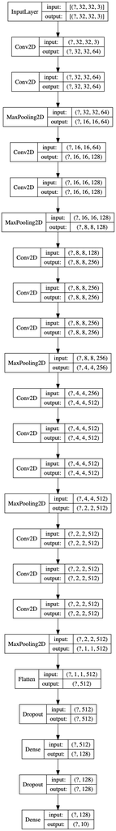

#### Answer 4.2, Embeddings (5p)

- Generate embeddings with the trained convolutional part of model_4_1 (without the dense layer)
- Embed the training and test data and store them to disk
- Build and evaluate a pipeline on the embedded data
  - Check if pipeline makes sense (e.g. use models that can handle many dimensions)
- Describe what you did and what you observed (max 800 chars).
  - Consider different models, preprocessing, tuning, etc.
  - Check performance (see original Submission.html) when in doubt. We did not run all the evaluations because it takes too long, and the output is ill-defined.

```
The two classifiers used in this exercise (KNN and RF) show that the model performs very good with the embeddings. Both classifiers obtain an accuracy of +/- 0.932. The best model so far (Q2.2) is not beaten, but it is a close. (length: 228)

Pipeline(steps=[('classifier',
                 KNeighborsClassifier(n_jobs=-1, n_neighbors=15))])
def store_embeddings(X_train, X_test):
    # load model 4.1 and the output of the maxpool layer after the last conv layer
    # model = load_model_from_file(base_dir, 'model_4_1')
    model = load_model_from_file(base_dir, 'model_4_1')
    model_output = model.get_layer('block5_pool').output
    conv_base = models.Model(inputs=model.input, outputs=model_output)

    sample_count_train = X_train.shape[0]
    sample_count_test = X_test.shape[0]

    features_train = np.zeros(shape=(sample_count_train, 1, 1, 512))
    features_test = np.zeros(shape=(sample_count_test, 1, 1, 512))

    # Set the batch size to 128
    batch_size=128

    # Generate image data generator for both sets
    generator_embed_train = tf.keras.preprocessing.image.NumpyArrayIterator(
        X_train,
        y=y_train,
        image_data_generator=ImageDataGenerator(),
        batch_size=batch_size)

    generator_embed_test = tf.keras.preprocessing.image.NumpyArrayIterator(
        X_test,
        y=y_test,
        image_data_generator=ImageDataGenerator(),
        batch_size=batch_size)

    i = 0
    for inputs_batch, labels_batch in generator_embed_train:
        features_batch = conv_base.predict(inputs_batch)
        features_train[i * batch_size : (i + 1) * batch_size] = features_batch
        i += 1
        if i * batch_size >= sample_count_train:
            break

    i = 0
    for inputs_batch, labels_batch in generator_embed_test:
        features_batch = conv_base.predict(inputs_batch)
        features_test[i * batch_size : (i + 1) * batch_size] = features_batch
        i += 1
        if i * batch_size >= sample_count_test:
            break

    # Reshape the feature embeddings to one dimension to be able to use them to classify
    features_train = np.reshape(features_train, (features_train.shape[0], 1 * 1 * 512))
    features_test = np.reshape(features_test, (features_test.shape[0], 1 * 1 * 512))

    return store_embedding(features_train, 'train_embed'), store_embedding(features_test, 'test_embed')

def evaluation_4_2(X_train, y_train, X_test, y_test):
    """ Runs 'evaluate_pipeline' with embedded versions of the input data
     and returns the accuracy.
      """
    return evaluate_pipeline(generate_pipeline(), load_embedding('train_embed'), y_train, load_embedding('test_embed'), y_test)
```

```
Running time: 30.04 seconds
Last modified: May 26, 2020
scikit-learn version: 0.23.1
```